# Regular guys talk regularization

## What we’ll talk aboout

- Why regularization
- What is it?
- How do I do it?
- Tweedie
- Mathy stuff
- Conclusion

# Why?

## Why?

Let’s start with some data and a model

## Data

- *dataOhlsson* from *insuranceData* R package
- Swedish motorcycle insurance from Wasa, 1994 to 1998
- We’ve renamed variables to English

```r
library(insuranceData)
data("dataOhlsson")

# Drop the claim count variable
tbl_ohlsson <- dataOhlsson %>%
  select(
    age_number = agarald
    , territory = zon
    , motor_class = mcklass
    , vehicle_age = fordald
    , bonus_class = bonuskl
    , duration
    , losses = skadkost)
```

```r
str(tbl_ohlsson)
```

```
## 'data.frame':    64548 obs. of  7 variables:
##  $ age_number : int  0 4 5 5 6 9 9 9 10 10 ...
##  $ territory  : int  1 3 3 4 2 3 4 4 2 4 ...
##  $ motor_class: int  4 6 3 1 1 3 3 4 3 2 ...
##  $ vehicle_age: int  12 9 18 25 26 8 6 20 16 17 ...
##  $ bonus_class: int  1 1 1 1 1 1 1 1 1 1 ...
##  $ duration   : num  0.175 0 0.455 0.173 0.181 ...
##  $ losses     : int  0 0 0 0 0 0 0 0 0 0 ...
```

## Fit a model

```r
fit_ols <- lm(
  losses ~ .
  , data = tbl_ohlsson
)
```

## Which coefficient should we drop?

```r
fit_ols %>%
  summary()
```

```
##
## Call:
## lm(formula = losses ~ ., data = tbl_ohlsson)
##
## Residuals:
##    Min     1Q Median     3Q    Max
##  -3231   -475   -273    -61 365055
##
## Coefficients:
##             Estimate Std. Error t value Pr(>|t|)
## (Intercept) 1179.278     95.404  12.361  < 2e-16 ***
## age_number   -11.948      1.461  -8.176 2.98e-16 ***
## territory   -114.157     13.731  -8.314  < 2e-16 ***
## motor_class    3.827     12.714   0.301   0.7634
## vehicle_age  -17.788      1.968  -9.040  < 2e-16 ***
## bonus_class   17.914      8.140   2.201   0.0278 *
## duration      94.150     14.443   6.519 7.13e-11 ***
## ---
## Signif. codes:  0 '***' 0.001 '**' 0.01 '*' 0.05 '.' 0.1 ' ' 1
##
## Residual standard error: 4684 on 64541 degrees of freedom
## Multiple R-squared:  0.004616,   Adjusted R-squared:  0.004523
## F-statistic: 49.88 on 6 and 64541 DF,  p-value: < 2.2e-16
```

## Options

- Manual selection based on standard error of coefficients
- Stepwise regression
- Feature engineering
- PCA
- Partial least squares
- Or …

## Regularization!

Benefits:

- “Curse of dimensionality” number of observations not much larger than $p$
- No p-hacking
- Let the model pick your variables!
- Reduce chance that the model will overfit
- Collinearity

# What

## What is regularization

Regluarization adjusts the cost function which creates the model

## The *what* function?

- Models map data (predictors) to other data (target variable)
- The preferred model is one which optimizes some *cost* of model output
- OLS cost -> least squares
- GLM -> maximum likelihood/residual deviance
- Regularization augments OLS/GLM with a penalty based on the magnitude of the coefficients

## OLS cost function

$$\sum_i^n{\left(y_i-\hat{y_i}\right)^2}=\sum_i^n{\left(y_i-\hat{\beta_0} -\sum_j^p\left(x_{ij}*\hat{\beta_j}\right)\right)}^2 = RSS$$

## Regularization cost function

$$\sum_i^n{\left(y_i-\hat{\beta_0} -\sum_j^p\left(x_{ij}*\hat{\beta_j}\right)\right)}^2 + \lambda\sum_j^p{\|\hat{\beta_j}\|}_L = RSS + \lambda\sum_j^p{\|\hat{\beta_j}\|_L}$$

## Two cost functions

**OLS**

$$\sum_i^n{\left(y_i-\hat{y_i}\right)^2}=\sum_i^n{\left(y_i-\hat{\beta_0} -\sum_j^p\left(x_{ij}*\hat{\beta_j}\right)\right)}^2 = RSS$$

**Regularization:**

$$\sum_i^n{\left(y_i-\hat{\beta_0} -\sum_j^p\left(x_{ij}*\hat{\beta_j}\right)\right)}^2 + \lambda\sum_j^p{\|\hat{\beta_j}\|}_L = RSS + \lambda\sum_j^p{\|\hat{\beta_j}\|_L}$$

## Overfitting and the role of $\lambda$

Analogue to credibility. $\lambda$ applies a shrinkage to the parameters. The “complement” is the intercept.

Same idea: reduce variance on out of sample data.

Control weight given to predictors (i.e. $\hat{\beta_j}$), in favor of $\hat{\beta_0}$.

## L?

$$\sum_j^p{\|\hat{\beta_j}\|_L}$$

$$L=1 \implies\sum_j^p{|\hat{\beta_j}|}$$

$$L=2 \implies\sum_j^p{\hat{\beta_j}^2}$$

## L

- Can L be higher than 2?
- Must L be an integer?

## L1 and L2 norms

L1 = **L**east **A**bsolute **S**hrinkage and **S**election **O**perator = LASSO

$$L=1\implies RSS + \lambda\sum_j^p|\beta_j|$$

L2 = Ridge regression

$$L=2\implies RSS + \lambda\sum_j^p{\beta_j}^2$$

# How

## Easy answer

Use `glmnet`

```r
mat_ohlsson <- tbl_ohlsson %>%
  select(-losses) %>%
  as.matrix()

library(glmnet)
fit_ridge <- glmnet(
  x = mat_ohlsson
  , y = tbl_ohlsson$losses
  , family = 'gaussian'
  , alpha = 0
)
```

## About `alpha`

Used to mix Ridge and Lasso

$$(1 - \alpha)/2\|\beta\|^2_2 + \alpha\|\beta\|_1$$

$$\alpha = 0 \implies Ridge$$

$$\alpha = 1 \implies Lasso$$

## What does `glmnet` do?

1. Standardize the predictor space (unless you tell it not to)
2. Form a set of candidate $\lambda$’s (unless you provide your own)
3. Fit coefficients for each $\lambda$

We should:

1. Use cross validation to measure RMSE (or other metric) on out of sample (test) data
2. Pick the $\lambda$ which optimizes out of sample predictions

## Standardize predictors

- Why?
- OLS is scale-invariant, regularization isn’t
- Extreme(ish) case: convert currency

```r
fit_ols %>%
  summary()
```

```
##
## Call:
## lm(formula = losses ~ ., data = tbl_ohlsson)
##
## Residuals:
##    Min     1Q Median     3Q    Max
##  -3231   -475   -273    -61 365055
##
## Coefficients:
##             Estimate Std. Error t value Pr(>|t|)
## (Intercept) 1179.278     95.404  12.361  < 2e-16 ***
## age_number   -11.948      1.461  -8.176 2.98e-16 ***
## territory   -114.157     13.731  -8.314  < 2e-16 ***
## motor_class    3.827     12.714   0.301   0.7634
## vehicle_age  -17.788      1.968  -9.040  < 2e-16 ***
## bonus_class   17.914      8.140   2.201   0.0278 *
## duration      94.150     14.443   6.519 7.13e-11 ***
## ---
## Signif. codes:  0 '***' 0.001 '**' 0.01 '*' 0.05 '.' 0.1 ' ' 1
##
## Residual standard error: 4684 on 64541 degrees of freedom
## Multiple R-squared:  0.004616,   Adjusted R-squared:  0.004523
## F-statistic: 49.88 on 6 and 64541 DF,  p-value: < 2.2e-16
```

## Fit using many different $\lambda$’s

[interactive chart not shown]

## What does lasso look like?

```r
fit_lasso <- glmnet(
    x = mat_ohlsson
  , y = tbl_ohlsson$losses
  , family = 'gaussian'
  , alpha = 1
)
```

## What does lasso look like?

[interactive chart not shown]

## Compare

[interactive chart not shown]

## Use cross validation to measure RMSE (or other metric) on out of sample (test) data

```r
fit_lasso_cv <- cv.glmnet(
    x = mat_ohlsson
  , y = tbl_ohlsson$losses
  , family = 'gaussian'
  , alpha = 1
)
```

## What is wrong here?

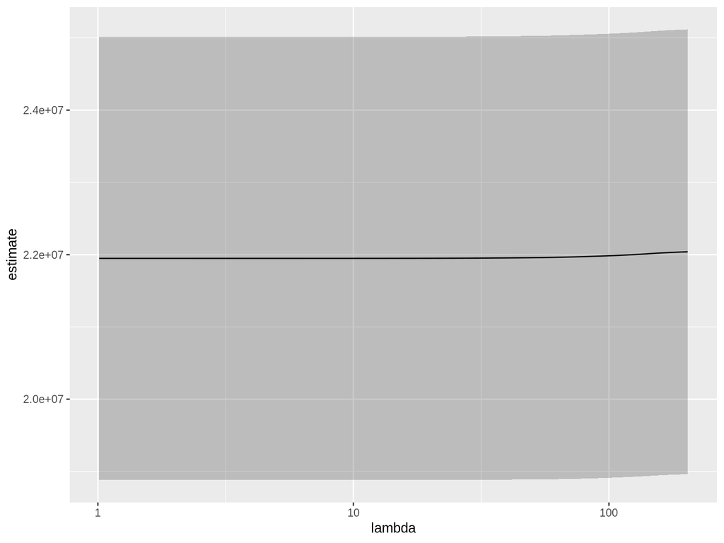

```r
#plot(fit_lasso_cv)
library(broom)
tidy(fit_lasso_cv) %>%
  ggplot(aes(lambda,estimate))+
  geom_line()+
  scale_x_log10()+
  geom_ribbon(aes(ymin = conf.low, ymax = conf.high), alpha = .25)
```

## Pick the $\lambda$ which optimizes out of sample predictions

```r
fit_lasso_cv$lambda.min
```

```
## [1] 3.722346
```

# The Tweedie distribution

## OLS but not so ordinary

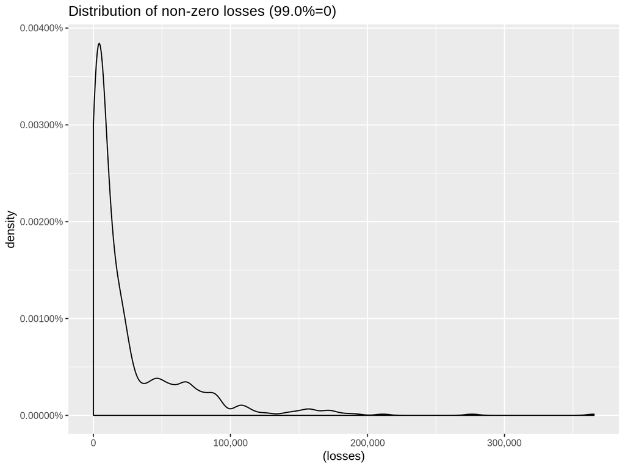

## One curve to rule them all

- Tweedie family contains any distribution that satisfies r:
  $$Variance = \phi* \mu^p$$
- This includes
  - Normal: $p=0$
  - Poisson: $p=1$
  - Compound Gamma/Poisson: $1<p<2$
  - Gamma: $p=2$
  - Inverse Gaussian: $p=3$
- Generally no closed form.

## GLM

```r
library(statmod)

fit_glm <- glm(
  losses ~ .
  , family = tweedie(var.power = 1.5, link.power = 0)
  , data = tbl_ohlsson
)

summary(fit_glm)
```

```
##
## Call:
## glm(formula = losses ~ ., family = tweedie(var.power = 1.5, link.power = 0),
##     data = tbl_ohlsson)
##
## Deviance Residuals:
##    Min      1Q  Median      3Q     Max
## -24.37   -8.28   -6.64   -5.27  384.42
##
## Coefficients:
##             Estimate Std. Error t value Pr(>|t|)
## (Intercept)  8.67935    0.75445  11.504  < 2e-16 ***
## age_number  -0.05368    0.01294  -4.149 3.35e-05 ***
## territory   -0.43013    0.11922  -3.608 0.000309 ***
## motor_class  0.06078    0.10692   0.569 0.569689
## vehicle_age -0.09108    0.02233  -4.078 4.55e-05 ***
## bonus_class  0.11721    0.07002   1.674 0.094134 .
## duration     0.14737    0.08492   1.735 0.082674 .
## ---
## Signif. codes:  0 '***' 0.001 '**' 0.01 '*' 0.05 '.' 0.1 ' ' 1
##
## (Dispersion parameter for Tweedie family taken to be 20386.43)
##
##     Null deviance: 7708506  on 64547  degrees of freedom
## Residual deviance: 6109806  on 64541  degrees of freedom
## AIC: NA
##
## Number of Fisher Scoring iterations: 25
```

## HDTweedie

- Package is built on glmnet, with addition of the Tweedie family
- We purposefully use the auto-selected lambdas from our prior modelling

```r
library(HDtweedie)
fit_ridge_cv_tweedie <- cv.HDtweedie(
  x = mat_ohlsson
  , y = tbl_ohlsson$losses
  , p = 1.5
  , alpha = 0
  , lambda = fit_ridge$lambda/exp(4.5)
  , standardize=TRUE#
)

fit_lasso_cv_tweedie <- cv.HDtweedie(
  x = mat_ohlsson
  , y = tbl_ohlsson$losses
  , p = 1.5
  , alpha = 1
  #, lambda = fit_lasso_cv$lambda/exp(2)
  , standardize=TRUE
)
```

## Compare Cross Validation

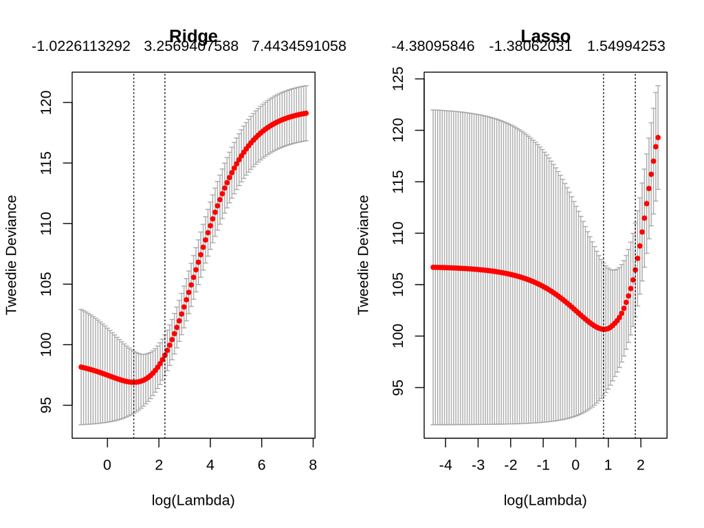

# Mathy stuff

## The formula again

$$\sum_i^n{\left(y_i-\hat{\beta_0} -\sum_j^p\left(x_{ij}*\hat{\beta_j}\right)\right)}^2 + \lambda\sum_j^p{\|\hat{\beta_j}\|}_L = RSS + \lambda\sum_j^p{\|\hat{\beta_j}\|_L}$$

## Equivalently

$$\sum_i^n{\left(y_i-\hat{\beta_0} -\sum_j^p\left(x_{ij}*\hat{\beta_j}\right)\right)}^2$$

Subject to:

$$\sum_j^p{\|\hat{\beta_j}\|_L}\leq{t}$$

## Shrink or vanish

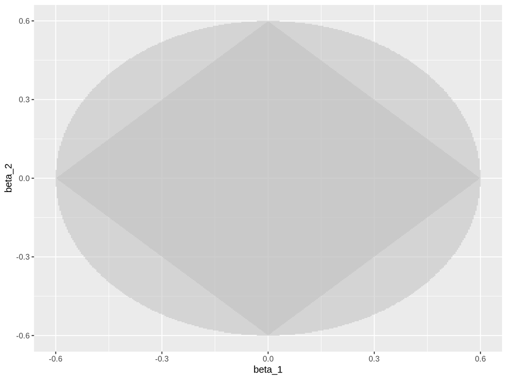

## The formulaic way of saying that

$$\beta = \frac{2x_iy_i-\lambda}{2x_i^2}$$

$$\beta = \frac{2x_iy_i}{2x_i^2+2\lambda}$$

## L0

Subject to:

$$\sum_j^p{\|\hat{\beta_j}\|_0}=\sum_j^p{I(\beta_j\neq0)}\leq{t}$$

No more than $t$ coefficients are not zero -> best subset.

## Collinearity

If we know both are important, we may not want to choose:

L1/LASSO pushes things to zero.

L2/Ridge restricts the size, but keeps both.

## Bayesian link

L1 = Bayes with Laplace prior

L2 = Bayes with normal priors

# Conclusion

## Conclusion

- Option to consider for high-dimension data
- Choice of hyperparameter needs a fair bit of data
- `glmnet` package or `HDtweedie`

Thank you!

## References

- http://www-bcf.usc.edu/~gareth/ISL/ISLR%20Seventh%20Printing.pdf
- https://web.stanford.edu/~hastie/Papers/ESLII.pdf